## How visible is the central bank when inflation fills the news?

[30th Young Statisticians Meeting](https://ysm5.eu/dir/)Mönichwald, Austria · 4 October 2026

# Reading the economy through the News: AI-assisted narrative and sentiment analysis of media text

How visible is the central bank when inflation fills the news?

[Luka Sikić](https://www.lukasikic.info/)

[Hrvatsko katoličko sveučilište](https://www.unicath.hr/en)

[Based on the working paper by Petra Palić and Luka Sikić, version of 28 September 2026](https://lusiki.github.io/HNB_Media_Attention/media/downloads/PAPER_EXT.html)

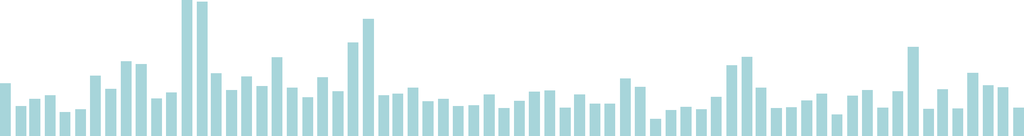

## Outline

Outline

1. **1**Introduction*3*
2. **2**Literature review*4*
3. **3**Data and methods*5*
4. **4**Results and discussion*6 to 15*
5. **5**Conclusions*16 to 18*
6. **6**Bibliography*19*

Keywords

central bank communicationmedia attentioninflationtext as datatime seriesAI-assisted text analysisCroatia

Numbers on the right are slide numbers2 / 19

## One question, one measure, one hypothesis

Introduction

TopicHow much room HNB, the Croatian central bank, gets in online news about inflation, 2021 to 2026

Research questionDoes HNB's share of inflation news shrink when inflation rises?

AimBuild a transparent, reproducible text measure of that share and test its link with inflation

HypothesisCrowding out: higher inflation brings more inflation news in total, so HNB's slice gets smaller

Paper, Sections 1 and 23 / 19

## What we build on, and the gap

Literature review

**Limited attention**Mankiw and Reis 2002 · Sims 2003

**Inflation and attention**Malmendier and Nagel 2016 · Bracha and Tang 2019

**News selection and framing**Entman 1993 · Shoemaker and Vos 2009

**Central bank communication**Woodford 2003 · Coibion, Gorodnichenko and Weber 2022

**Methods**Newey and West 1987 · Jordà 2005

**Research gap**We know a lot about whether central bank messages move expectations. We know little about how much of the inflation conversation the bank actually holds in the news, and how that share moves with inflation.

Full references on the last slide4 / 19

## Data and methods

Data and methods

Data

**Croatian digital media archive**42.3 million news items and posts, 1 January 2021 to 10 September 2026, with headline, text, source, reach and tone label

**Two text corpora**Items naming HNB or the central bank, and all inflation news

**Inflation**Croatian HICP, annual rate, Eurostat

**Checks**EC consumer survey, euro area food and energy HICP, FAO Food Price Index

Methods

**Measure**Keyword search, rule based prominence score, reach weighted share and attention gap

**Model**Time series regression, 295 weeks and 67 months, Newey West errors

**Robustness**Alternative measures, leave one month out, block permutation, instruments

**Dynamics**Local projections on consumer price expectations

Paper, Sections 3 and 4. Software: R with duckdb, data.table and igraph, Quarto for the paper and slides5 / 19

## HNB is in the Croatian news every day

Results and discussionHNB in the news

29

**items a day** name HNB2,403 sources · January 2021 to August 2026

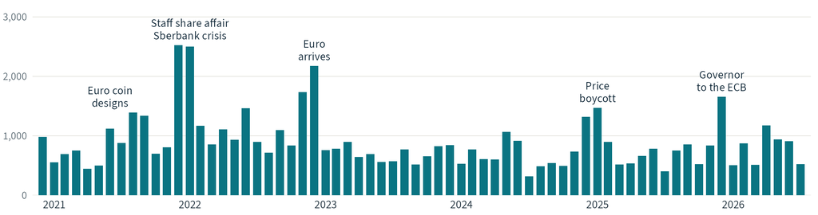

Items per month that name HNB or Hrvatska narodna banka. Own count from the paper's article data. A bookshop and a car ad site that only quote the HNB exchange rate are left out6 / 19

## Euro and prices lead the headlines around HNB

Results and discussionHNB in the news

Share of headlines that mention each topic, among items naming HNB

Euro and kuna

**22%**about 1 in 5

Prices and inflation

**12%**about 1 in 8

The governor

**9%**about 1 in 11

Loans and interest

**9%**about 1 in 11

Own count of headline words in 59,614 headlines, January 2021 to August 2026. A headline can mention more than one topic7 / 19

## In 2022 HNB had more inflation stories but a smaller slice

Results and discussionHNB in the news

|  | 2021 |  | 2022 |  |
| --- | --- | --- | --- | --- |
| Inflation stories with HNB | 8,419 | → | 17,278 | twice as many |
| All inflation stories | 40,639 | → | 129,932 | three times as many |
| HNB's slice | 21% | → | 13% | smaller |

More stories, smaller slice.

Paper, Table 1. Inflation was 2.7% in 2021 and 10.7% in 20228 / 19

## A headline story counts more than a passing mention

Results and discussionHow we measure

1. Article
2. Score
3. Share
4. Result

Our article · English summary

[HNB expects average inflation of 7.7% in 2023](https://www.index.hr/vijesti/clanak/hnb-inflacija-bi-na-razini-cijele-2023-mogla-iznositi-oko-77-posto/2475803.aspx)

Index.hr · 30 June 2023

**0.97**HNB at the centre

Comparison · English summary

[Minister demands a return to earlier prices](https://www.index.hr/vijesti/clanak/onaj-filipovic-snizite-cijene-na-razinu-s-kraja-godine-ako-to-ne-napravite/2426690.aspx)

Index.hr · 5 January 2023

**0.07**One passing mention

Score from 0 to 1,  
four questions

In the headline?

Named early?

Named often?

Acts or is quoted?

Scores from the 28 September data. Weights 0.30 headline, 0.25 position, 0.20 frequency, 0.25 action or source. Headlines link to the public articles9 / 19

## More inflation news shrinks HNB’s share

Results and discussionHow we measure

1. Article
2. Score
3. Share
4. Result

HNB items  
score × reach

All inflation news  
reach

Larger share

Smaller share

**HNB share**teal pile ÷ grey pile

**Attention gap**early 2021 share, about 5%, minus today's share

Paper, Section 3.2. Reach is the data vendor's estimate of an outlet's possible audience. It is a weight, not a count of readers10 / 19

## HNB’s share fell in the inflation surge and stayed low

Results and discussionHow we measure

1. Article
2. Score
3. Share
4. Result

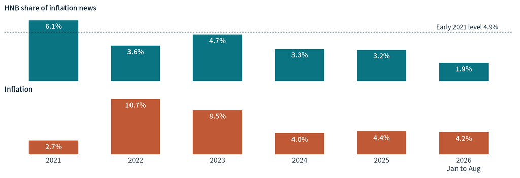

Our June 2023 article is one of 13,365 HNB inflation items that year.

Paper, Table 1. Yearly weighted share. Early 2021 level is the January to June 2021 average. 2026 covers January to August11 / 19

## Higher inflation goes with a wider attention gap

Results and discussionThe estimate

1. Article
2. Score
3. Share
4. Result

0.25

percentage points wider gap  
per point of inflationfor the same amount of HNB coverage

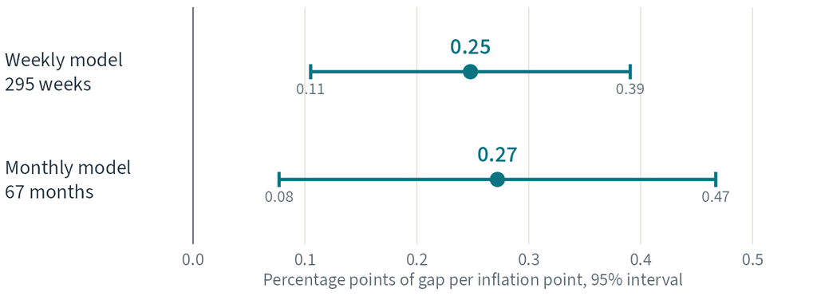

2% → 10% inflation≈gap about 2 points widerThe starting share  
was about 5%

Paper, Table 2. 95% Newey West intervals. The model also holds fixed the change in inflation, the euro, source concentration and the number of HNB items12 / 19

## Robust across measures, sensitive to year controls

Results and discussionThe estimate

1. Article
2. Score
3. Share
4. Result

interval above zerointerval includes zero

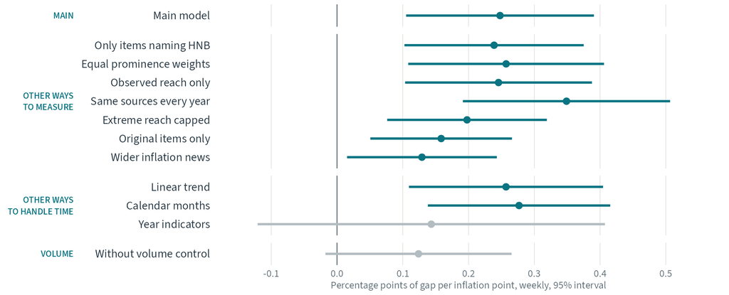

Paper, Tables 2 and 4. Weekly models, 95% intervals13 / 19

## Most HNB inflation news is labelled negative

Results and discussionTone and AI

Share of HNB inflation items with a negative tone label

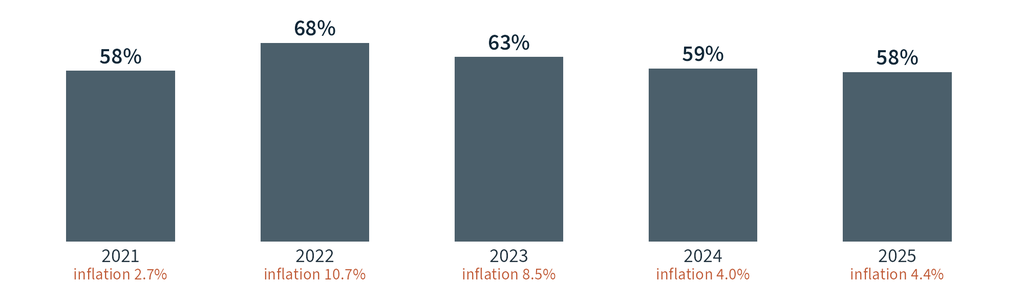

**Caveat**The labels come from the data vendor and have not yet been checked against human readers

Own count, full calendar years 2021 to 2025. Inflation from the paper, Table 114 / 19

## AI can check what our simple rules miss

Results and discussionTone and AI

Planned · not yet done

1FindWhich bank? Is it even news?

2WeighHow central is HNB in the story?

3ToneIs the tone label right?

4StoryWhat explanation does the article give?

**The test**400 articles coded by two people, then the AI is checked against them

Validation design from the project plan of 22 September 2026. No AI coding has been run yet15 / 19

## Our article shows what was said, not what was understood

ConclusionsWhat text cannot tell us

1. Article
2. Score
3. Share
4. Result

Our article · English summary

[HNB expects average inflation of 7.7% in 2023](https://www.index.hr/vijesti/clanak/hnb-inflacija-bi-na-razini-cijele-2023-mogla-iznositi-oko-77-posto/2475803.aspx)

Index.hr · 30 June 2023 · score 0.97

*✓*Published

*✓*HNB at the centre

*?*Read

*?*Understood

*?*Changed expectations

[Index.hr public article](https://www.index.hr/vijesti/clanak/hnb-inflacija-bi-na-razini-cijele-2023-mogla-iznositi-oko-77-posto/2475803.aspx), 30 June 202316 / 19

## Conclusions and limitations

Conclusions

Conclusions

**Crowding out**Higher inflation goes with a smaller HNB slice of inflation news, 0.25 weekly and 0.27 monthly

**Count, not reach**The link runs mainly through fewer HNB stories relative to all inflation stories

**No return**After inflation fell, HNB's share stayed low

**Expectations**No stable link between the gap and later consumer price expectations

Limitations

**Association**Not a causal effect, and sensitive to year indicators

**Reach**A weight for possible audience, not a count of readers

**Keywords**Central bank can mean the ECB, and tone labels are the vendor's

**Text only**Shows what was said, not what was understood

Paper, Sections 6 and 7, Tables 2 and 317 / 19

## Three key takeaways

ConclusionsKey takeaways

**1**HNB is in the news every day, but its slice of inflation news shrank when inflation rose, and has not come back

**2**For the same HNB coverage, one point more inflation goes with a gap 0.25 points wider

**3**AI can sharpen every step, if we check it against people

Next step: read the story behind the headline.

Luka Sikić · Hrvatsko katoličko sveučilište · 30th Young Statisticians Meeting18 / 19

## Bibliography

Bibliography

- Bracha, A., & Tang, J. (2019). *Inflation thresholds and inattention* (Working Paper 19-14). Federal Reserve Bank of Boston.
- Coibion, O., Gorodnichenko, Y., & Weber, M. (2022). Monetary policy communications and their effects on household inflation expectations. *Journal of Political Economy, 130*(6), 1537–1584.
- Entman, R. M. (1993). Framing: Toward clarification of a fractured paradigm. *Journal of Communication, 43*(4), 51–58.
- Food and Agriculture Organization of the United Nations. (2026). *FAO Food Price Index*. Monthly nominal series.
- Jordà, Ò. (2005). Estimation and inference of impulse responses by local projections. *American Economic Review, 95*(1), 161–182.
- Malmendier, U., & Nagel, S. (2016). Learning from inflation experiences. *The Quarterly Journal of Economics, 131*(1), 53–87.
- Mankiw, N. G., & Reis, R. (2002). Sticky information versus sticky prices: A proposal to replace the New Keynesian Phillips curve. *The Quarterly Journal of Economics, 117*(4), 1295–1328.
- Newey, W. K., & West, K. D. (1987). A simple, positive semi-definite, heteroskedasticity and autocorrelation consistent covariance matrix. *Econometrica, 55*(3), 703–708.
- Palić, P., & Sikić, L. (2026). *Pasivno zamijenjena: cijena inflacije koju ne mjeri indeks potrošačkih cijena* [Working paper, version of 28 September 2026]. Hrvatsko katoličko sveučilište.
- Shoemaker, P. J., & Vos, T. P. (2009). *Gatekeeping theory*. Routledge.
- Sims, C. A. (2003). Implications of rational inattention. *Journal of Monetary Economics, 50*(3), 665–690.
- Woodford, M. (2003). *Interest and prices: Foundations of a theory of monetary policy*. Princeton University Press.

Data: Croatian digital media archive, Eurostat HICP, European Commission consumer survey · Thank you19 / 19